# Simplification Logic using fcaR

- and how closures are interesting to develop recommenders

P. Cordero, M. Enciso, A. Mora, D. López

2021-07-01

# Moving towards applications

How to guide an user (users) in a recommendation system?

- Closures of preferences of the users - blindly
- Closures of preferences of the users - guided by attributes on the left-hand side of the implications
- Preferences of the users - guided by attributes on minimal generators
- Some of the above options enhanced by parallelism and/or cooperative user guidance

> > A Formal Concept Analysis approach to cooperative conversational recommendation . P. Cordero, M. Enciso, A. Mora, M. Ojeda, C. Rossi - International Journal of Computational Intelligence Systems (2020) 13(1) 1243–1252

The knowledge inside the implications addresses us towards the development of some recommender systems.

- Based on logic which allows to manage the users’ preferences by following a conversational paradigm.
- Lazzy computation of minimal generators - on-demand computation of minimal generators by means of an algorithm with polynomial delay.

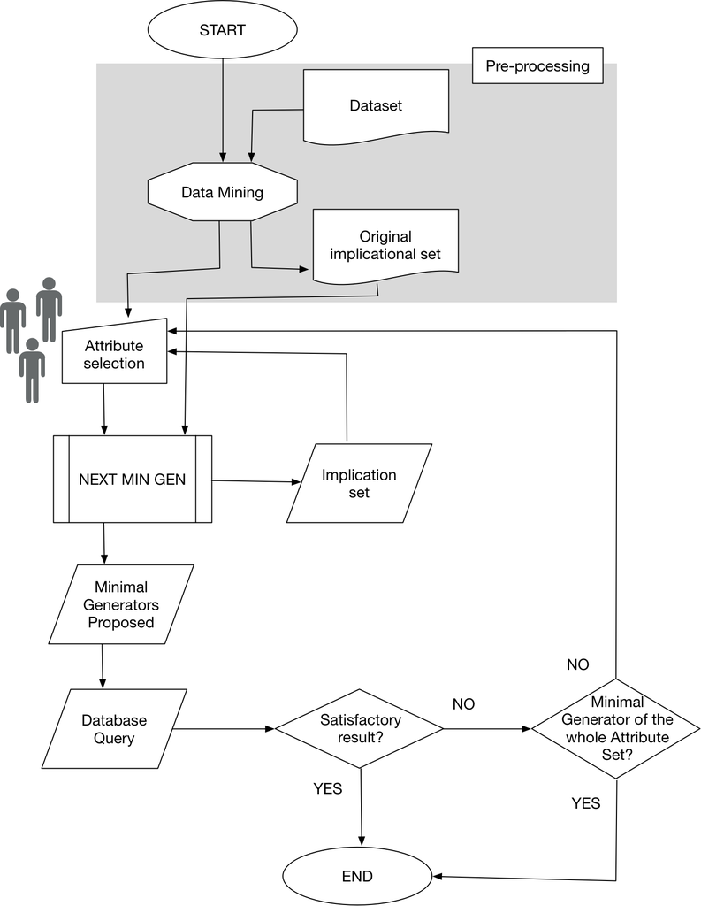

Results:

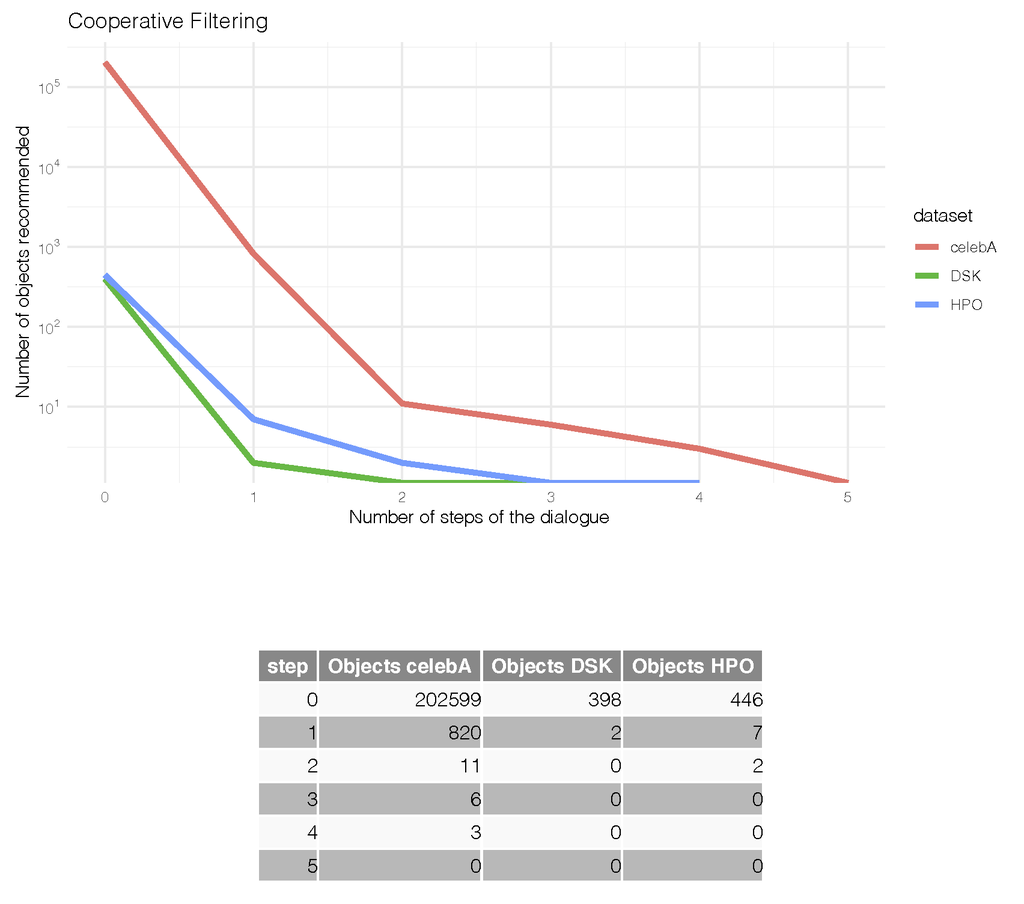

> > A conversational recommender system for diagnosis using fuzzy rules. P. Cordero, M. Enciso, D. López, A. Mora - Expert Systems With Applications 154 (2020) 113449

Graded implications in the framework of Fuzzy Formal Concept Analysis are used as the knowledge guiding the recommendations.

- Conversational recommender systems have proven to be a good approach in telemedicine, building a dialogue between the user and the recommender based on user preferences provided at each step of the conversation.
- We propose a conversational recommender system for medical diagnosis using fuzzy logic.
- The recommender system has been used to provide differential diagnosis between schizophrenia and schizoaffective and bipolar disorders.

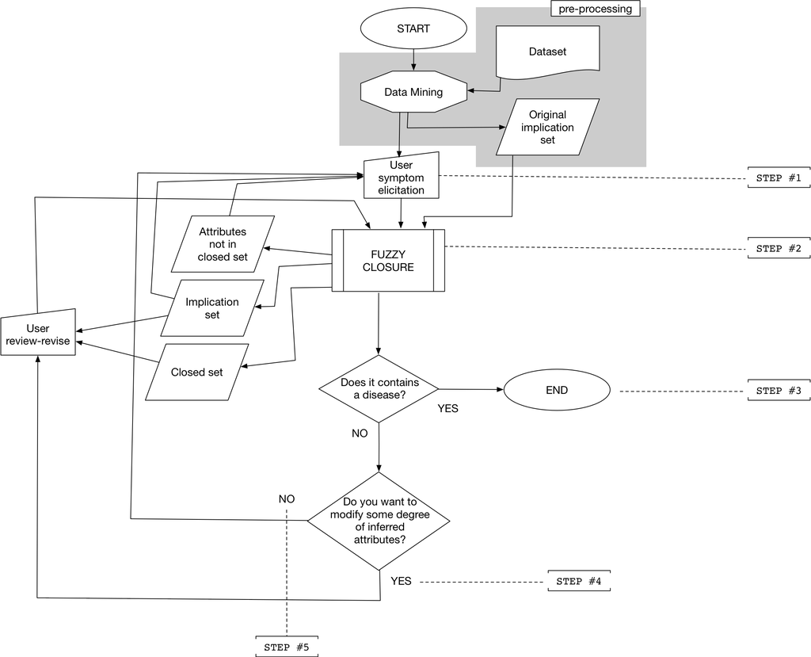

We have obtained the following results in a extensive comparative:

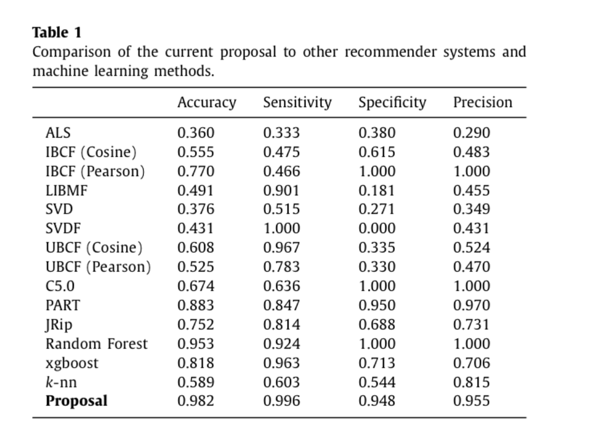

# Recommenders Systems using Simplification Logic

- Computation of closures
- Computation of Minimal Generators
- Computation of Lazzy Minimal Generators

> > … to develop automated reasoning methods.

References:

> > Angel Mora, Pablo Cordero, Manuel Enciso, Inmaculada Fortes, Gabriel Aguilera: Closure via functional dependence simplification. Int. J. Comput. Math. 89(4): 510-526 (2012) [Journal Link](https://www.tandfonline.com/doi/full/10.1080/00207160.2011.644275)

> > Pablo Cordero, Manuel Enciso, Angel Mora, Manuel Ojeda-Aciego: Computing Minimal Generators from Implications: a Logic-guided Approach. CLA 2012: 187-198 [PDF](http://ceur-ws.org/Vol-972/paper16.pdf)

> > Pablo Cordero, Manuel Enciso, Angel Mora, Manuel Ojeda-Aciego, Carlos Rossi: Knowledge discovery in social networks by using a logic-based treatment of implications. Knowl. Based Syst. 87: 16-25 (2015) [KBS Link](https://www.sciencedirect.com/science/article/abs/pii/S0950705115002725?via%3Dihub)

> > Estrella Rodríguez Lorenzo, Kira V. Adaricheva, Pablo Cordero, Manuel Enciso, Angel Mora: Formation of the D-basis from implicational systems using Simplification logic. Int. J. Gen. Syst. 46(5): 547-568 (2017) [Taylor Link](https://www.tandfonline.com/doi/full/10.1080/03081079.2017.1349632)

> > Fernando Benito Picazo, Pablo Cordero, Manuel Enciso, Angel Mora: Minimal generators, an affordable approach by means of massive computation. J. Supercomput. 75(3): 1350-1367 (2019) [J. Supercomputing Link](https://link.springer.com/article/10.1007/s11227-018-2453-z)

> > A Formal Concept Analysis Approach to Cooperative Conversational Recommendation. Int. J. Comput. Intell. Syst. 13(1): 1243-1252 (2020) [I.J.Comp.Intel.Syst.](https://www.atlantis-press.com/journals/ijcis/125943387)

> > Pablo Cordero, Manuel Enciso, Domingo López-Rodríguez, Angel Mora: A conversational recommender system for diagnosis using fuzzy rules. Expert Syst. Appl. 154: 113449 (2020) [J. Expert Systems Link](https://www.sciencedirect.com/science/article/abs/pii/S0957417420302736?via%3Dihub)

# fcaR package

- https://github.com/Malaga-FCA-group/fcaR
- More than 11000 downloads
- R language is one of the main tools in Machine Learning, Data Science, Big Data, etc.
- **Reproducible Research: theoretical content + code R or Python or … + dataset - sharing with people - reproducible results**
- Promoting people using R language in these areas to know FCA

# First Experiment

```
We import the formal context from a matrix to a  fcaR object named gradedfc.
```

In Table 1, we show the dataset used in these examples. The dataset simulate a set of 8 subjects and 6 symptom attributes with degrees ranging in [0, 1]. The symptoms are named a, b, c, d, e, f. Two possible diseases are denoted as D1 and D2.

```r
library(fcaR)
mymatrix <- read.csv2("~/Github/2021_ICFCARules_MinGen_Filtering/data/data_matrix.csv")
gradedfc <- fcaR:::FormalContext$new(mymatrix)
gradedfc
```

```
FormalContext with 8 objects and 8 attributes.
      a     b     c     d     e     f    D1   D2
  1   1    0.5    0     0     0    0.5   0    1
  2   1    0.5   0.5   0.5    1     0    0    1
  3  0.5    1     0     1    0.5    1    1    0
  4   1    0.5    0     0     0     1    0    1
  5   0     1     1     0     1     0    1    0
  6   0    0.5    1     0     0     0    0    1
  7   1    0.5    1     1     1     0    0    1
  8   1     0     1     1     1    0.5   1    0
```

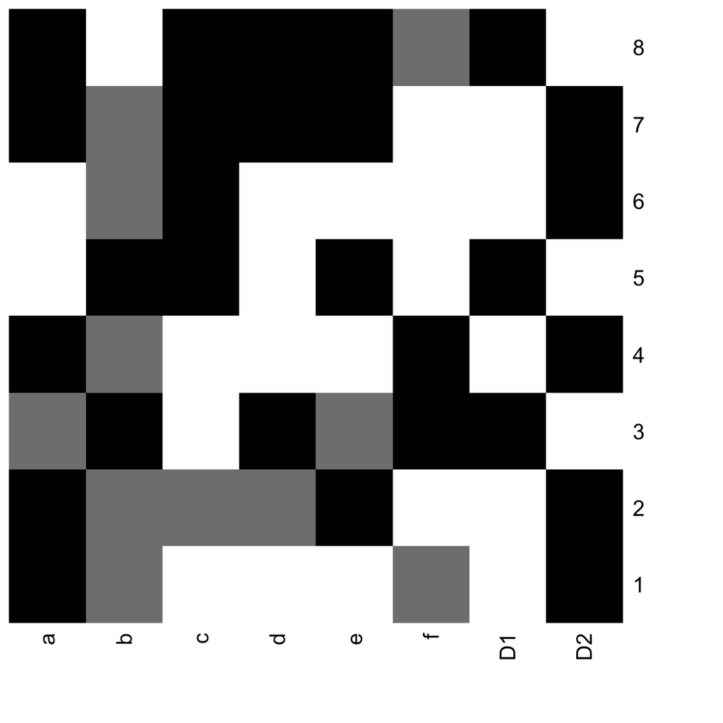

```r
plot(gradedfc)
```

> > Implications are computed using NextClosure (fuzzy version) from Radim Belohlavek.

> > For classical case, Nextclosure algorithm is developed in fcaR.

> > Now, we are developing the main algorithms to compute concept lattice and implications: FCbO, Fast Close-by-One, LinCbO, In-close.

```r
gradedfc$find_implications()
gradedfc$implications$cardinality()
```

```
[1] 21
```

```r
gradedfc$implications
```

```
Implication set with 21 implications.
Rule 1: {D2 [0.5]} -> {b [0.5], D2}
Rule 2: {D1 [0.5]} -> {e [0.5], D1}
Rule 3: {f [0.5]} -> {a [0.5]}
Rule 4: {d [0.5]} -> {a [0.5], e [0.5]}
Rule 5: {c [0.5], e [0.5]} -> {e}
Rule 6: {c [0.5], e, D1} -> {c}
Rule 7: {b [0.5], e [0.5], D2} -> {a, c [0.5], d [0.5], e}
Rule 8: {b [0.5], e [0.5], D1} -> {b}
Rule 9: {b, c [0.5]} -> {c}
Rule 10: {a [0.5], e [0.5]} -> {d [0.5]}
Rule 11: {a [0.5], d [0.5], e [0.5], D1} -> {d, f [0.5]}
Rule 12: {a [0.5], d [0.5], e [0.5], f [0.5]} -> {d, D1}
Rule 13: {a [0.5], d [0.5], e} -> {a}
Rule 14: {a [0.5], c [0.5]} -> {a, d [0.5], e}
Rule 15: {a [0.5], b [0.5], D2} -> {a}
Rule 16: {a [0.5], b, f [0.5]} -> {f}
Rule 17: {a [0.5], b, d [0.5], e [0.5]} -> {d}
Rule 18: {a, d [0.5], e [0.5]} -> {e}
Rule 19: {a, c [0.5], d, e} -> {c}
Rule 20: {a, c, d [0.5], e} -> {d}
Rule 21: {a, b [0.5], c [0.5], d [0.5], e} -> {D2}
```

```r
implications <- gradedfc$implications$clone()
```

This set of implications is used as the core knowledge of a Conversational recommender.

**Iteration 1:**

We’ll use the following subject data as starting point in the example conversations:

```r
Subject <- Set$new(attributes = gradedfc$attributes, sparse = TRUE)
Subject$assign(attributes = c("a"), values = c(1))
Subject
```

```
{a}
```

The computed closure is:

```r
closure <- implications$closure(Subject, reduce = TRUE)
closure
```

```
$closure
{a}

$implications
Implication set with 17 implications.
Rule 1: {D2 [0.5]} -> {b [0.5], D2}
Rule 2: {D1 [0.5]} -> {e [0.5], D1}
Rule 3: {d [0.5]} -> {e [0.5]}
Rule 4: {c [0.5], e, D1} -> {c}
Rule 5: {b [0.5], e [0.5], D2} -> {c [0.5], d [0.5], e}
Rule 6: {b [0.5], e [0.5], D1} -> {b}
Rule 7: {b, c [0.5]} -> {c}
Rule 8: {e [0.5]} -> {d [0.5]}
Rule 9: {d [0.5], e [0.5], D1} -> {d, f [0.5]}
Rule 10: {d [0.5], e [0.5], f [0.5]} -> {d, D1}
Rule 11: {c [0.5]} -> {d [0.5], e}
Rule 12: {b, f [0.5]} -> {f}
Rule 13: {b, d [0.5], e [0.5]} -> {d}
Rule 14: {d [0.5], e [0.5]} -> {e}
Rule 15: {c [0.5], d, e} -> {c}
Rule 16: {c, d [0.5], e} -> {d}
Rule 17: {b [0.5], c [0.5], d [0.5], e} -> {D2}
```

After applying Simplification Logic, the resulting set of simplified implications is:

```r
implications <- closure$implications
implications
```

```
Implication set with 17 implications.
Rule 1: {D2 [0.5]} -> {b [0.5], D2}
Rule 2: {D1 [0.5]} -> {e [0.5], D1}
Rule 3: {d [0.5]} -> {e [0.5]}
Rule 4: {c [0.5], e, D1} -> {c}
Rule 5: {b [0.5], e [0.5], D2} -> {c [0.5], d [0.5], e}
Rule 6: {b [0.5], e [0.5], D1} -> {b}
Rule 7: {b, c [0.5]} -> {c}
Rule 8: {e [0.5]} -> {d [0.5]}
Rule 9: {d [0.5], e [0.5], D1} -> {d, f [0.5]}
Rule 10: {d [0.5], e [0.5], f [0.5]} -> {d, D1}
Rule 11: {c [0.5]} -> {d [0.5], e}
Rule 12: {b, f [0.5]} -> {f}
Rule 13: {b, d [0.5], e [0.5]} -> {d}
Rule 14: {d [0.5], e [0.5]} -> {e}
Rule 15: {c [0.5], d, e} -> {c}
Rule 16: {c, d [0.5], e} -> {d}
Rule 17: {b [0.5], c [0.5], d [0.5], e} -> {D2}
```

**Iteration 2:**

The user select other attribute:

```r
Subject$assign(attributes = c("e"), values = c(1))
Subject
```

```
{a, e}
```

The computed closure is:

```r
closure <- implications$closure(Subject, reduce = TRUE)
closure
```

```
$closure
{a, d [0.5], e}

$implications
Implication set with 13 implications.
Rule 1: {D1} -> {d, f [0.5]}
Rule 2: {f [0.5]} -> {d, D1}
Rule 3: {b} -> {d}
Rule 4: {c [0.5], d} -> {c}
Rule 5: {c} -> {d}
Rule 6: {D1 [0.5]} -> {D1}
Rule 7: {c [0.5], D1} -> {c}
Rule 8: {b [0.5], D2} -> {c [0.5]}
Rule 9: {b [0.5], D1} -> {b}
Rule 10: {b [0.5], c [0.5]} -> {D2}
Rule 11: {D2 [0.5]} -> {b [0.5], D2}
Rule 12: {b, c [0.5]} -> {c}
Rule 13: {b, f [0.5]} -> {f}
```

After applying Simplification Logic, the resulting set of simplified implications is:

```r
implications <- closure$implications
implications
```

```
Implication set with 13 implications.
Rule 1: {D1} -> {d, f [0.5]}
Rule 2: {f [0.5]} -> {d, D1}
Rule 3: {b} -> {d}
Rule 4: {c [0.5], d} -> {c}
Rule 5: {c} -> {d}
Rule 6: {D1 [0.5]} -> {D1}
Rule 7: {c [0.5], D1} -> {c}
Rule 8: {b [0.5], D2} -> {c [0.5]}
Rule 9: {b [0.5], D1} -> {b}
Rule 10: {b [0.5], c [0.5]} -> {D2}
Rule 11: {D2 [0.5]} -> {b [0.5], D2}
Rule 12: {b, c [0.5]} -> {c}
Rule 13: {b, f [0.5]} -> {f}
```

**Iteration 3:**

The user select other attribute:

```r
Subject$assign(attributes = c("b"), values = c(0.5))
Subject
```

```
{a, b [0.5], e}
```

The computed closure is:

```r
closure <- implications$closure(Subject, reduce = TRUE)
closure
```

```
$closure
{a, b [0.5], e}

$implications
Implication set with 12 implications.
Rule 1: {D1} -> {b, d, f [0.5]}
Rule 2: {f [0.5]} -> {d, D1}
Rule 3: {b} -> {d}
Rule 4: {c [0.5], d} -> {c}
Rule 5: {c} -> {d}
Rule 6: {D1 [0.5]} -> {D1}
Rule 7: {c [0.5], D1} -> {c}
Rule 8: {D2} -> {c [0.5]}
Rule 9: {c [0.5]} -> {D2}
Rule 10: {D2 [0.5]} -> {D2}
Rule 11: {b, c [0.5]} -> {c}
Rule 12: {b, f [0.5]} -> {f}
```

After applying Simplification Logic, the resulting set of simplified implications is:

```r
implications <- closure$implications
implications
```

```
Implication set with 12 implications.
Rule 1: {D1} -> {b, d, f [0.5]}
Rule 2: {f [0.5]} -> {d, D1}
Rule 3: {b} -> {d}
Rule 4: {c [0.5], d} -> {c}
Rule 5: {c} -> {d}
Rule 6: {D1 [0.5]} -> {D1}
Rule 7: {c [0.5], D1} -> {c}
Rule 8: {D2} -> {c [0.5]}
Rule 9: {c [0.5]} -> {D2}
Rule 10: {D2 [0.5]} -> {D2}
Rule 11: {b, c [0.5]} -> {c}
Rule 12: {b, f [0.5]} -> {f}
```

This gives a total of 12 implications in this step, instead of the initial 21 implications. As we haven’t arrived to a valid class (D1, D2) in the closure, we proceed with the next iteration.

**Iteration 4:**

The user select other attribute:

```r
Subject$assign(attributes = c("c"), values = c(0.5))
Subject
```

```
{a, b [0.5], c [0.5], e}
```

The computed closure is:

```r
closure <- implications$closure(Subject, reduce = TRUE)
closure
```

```
$closure
{a, b [0.5], c [0.5], e, D2}

$implications
Implication set with 7 implications.
Rule 1: {D1} -> {b, c, d, f [0.5]}
Rule 2: {b} -> {c, d}
Rule 3: {d} -> {c}
Rule 4: {c} -> {d}
Rule 5: {b, f [0.5]} -> {f}
Rule 6: {f [0.5]} -> {d, D1}
Rule 7: {D1 [0.5]} -> {D1}
```

After applying Simplification Logic, the resulting set of simplified implications is:

```r
implications <- closure$implications
implications
```

```
Implication set with 7 implications.
Rule 1: {D1} -> {b, c, d, f [0.5]}
Rule 2: {b} -> {c, d}
Rule 3: {d} -> {c}
Rule 4: {c} -> {d}
Rule 5: {b, f [0.5]} -> {f}
Rule 6: {f [0.5]} -> {d, D1}
Rule 7: {D1 [0.5]} -> {D1}
```

# Second Experiment

This experiment has been done using the dataset named **Disease-Symptom Knowledge Database** containing a list of diseases given to a set of symptoms. See http://people.dbmi.columbia.edu/~friedma/Projects/DiseaseSymptomKB/index.html for more information about the dataset. The data in CSV format has been extracted from https://github.com/anaymalpani/sytora.

In this document, we present an idea of how closures and implications reduced in the computation of the closures the execution traces of how we develop the recommender system.

## Importing the dataset

```
   Disease C0000727 C0000731 C0000737 C0000786 C0000809 C0001122 C0001127
1 C0001175        0        0        0        0        0        0        0
2 C0001206        0        0        0        0        0        0        0
3 C0001339        0        0        1        0        0        0        0
  C0001824 C0001883 C0001925 C0002064 C0002170 C0002416 C0002418 C0002453
1        0        0        0        0        0        0        0        0
2        0        0        0        0        0        0        0        0
3        0        0        0        0        0        0        0        0
  C0002622 C0002726 C0002871 C0002878 C0002880 C0002888 C0002962 C0003123
1        0        0        0        0        0        0        0        0
2        0        0        0        0        0        0        0        0
3        0        0        0        0        0        0        0        0
 [ reached 'max' / getOption("max.print") -- omitted 3 rows ]
```

The size of the dataset is:

```r
dim(FC)
```

```
[1]  398 1016
```

## Using arules

In Machine Learning Community the most used R package to manipulate rules is `arules`. Our R package named fcaR (https://github.com/Malaga-FCA-group/fcaR) has an intersting interface with arules:

- **promoting Machine Learning community to approach FCA community**

We extract the rules using arules:

```r
rm(Rules, Rules1)
my_support <- 0.005
rule_param = list(supp = my_support, conf = 1, maxlen = 25)
Rules <- apriori(FC1, parameter = rule_param)
Rules1 <- Rules[!is.redundant(Rules)]
cat("Non-redundant rules:n")
Rules1
arules::write.PMML(Rules1, "~/Github/2021_ICFCARules_MinGen_Filtering/Rules1_DSK.pmml")
```

> > 10013234 implications extracted from the dataset using arules

> > Removing redundancy using method included in arules: 11844 implications

## Importing rules to fcaR

```r
Rules1 <- arules:::read.PMML("~/Github/2021_ICFCARules_MinGen_Filtering/Rules1_DSK.pmml")
Rules1
```

```
set of 11844 rules
```

```r
fcaR_fc <- fcaR:::FormalContext$new(FC1)
fcaR_fc
```

```
FormalContext with 398 objects and 1016 attributes.
      C0000727   C0000731   C0000737   C0000786   C0000809   C0001122   C0001127
   1
   2
   3                           X
   4                           X
   5
   6
   7
   8
   9
  10
Other attributes are: C0001824, C0001883, C0001925, C0002064, C0002170,
C0002416, ...
```

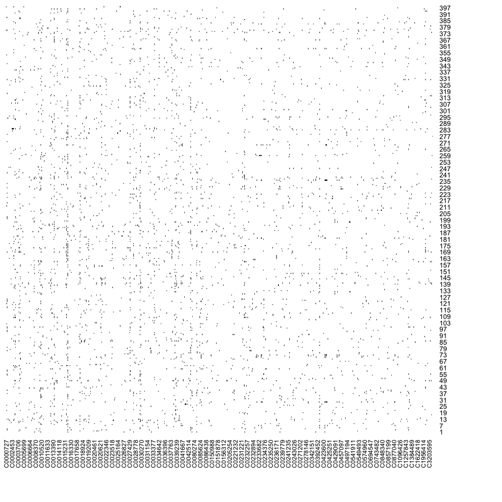

```r
plot(fcaR_fc)
```

```r
fcaR_fc$implications$add(Rules1)
fcaR_fc$implications$cardinality()
```

```
[1] 11844
```

```r
head(fcaR_fc$implications)
```

```
Implication set with 6 implications.
Rule 1: {C0220983} -> {C0020621}
Rule 2: {C0220983} -> {C0020538}
Rule 3: {C0013595} -> {C0033860}
Rule 4: {C0040586} -> {C0032285}
Rule 5: {C0040252} -> {C0033860}
Rule 6: {C0041976} -> {C0003864}
```

## Removing redundancy

First, we emphasize that simply applying the rules of Simplification Logic we can obtain a reduced set of implications. Using `fcaR` package the removing of redundancy can do in the following:

```r
fcaR_fc$implications$apply_rules(rules = c("generalization", "composition", "simplification"),
    parallelize = TRUE)
fcaR_fc$implications$cardinality()
```

```
[1] 4113
```

```r
implications <- fcaR_fc$implications$clone()
head(implications)
```

```
Implication set with 6 implications.
Rule 1: {C0220983} -> {C0020538, C0020621}
Rule 2: {C0013595} -> {C0033860}
Rule 3: {C0040586} -> {C0032285}
Rule 4: {C0040252} -> {C0033860}
Rule 5: {C0041976} -> {C0003864}
Rule 6: {C0027726} -> {C0020538, C0033687}
```

## Using closures

This set of implications is used as the core knowledge of a recommender system.

> > We simulate a conversation process with a doctor trying to identify a disease. For instance, objects could be POI (points of interest) in a touristic place and attributes some desired features for a restaurant that I am searching.

We’ll use the following subject data as starting point in the example conversations:

```r
Subject <- Set$new(attributes = fcaR_fc$attributes, sparse = TRUE)
Subject$assign(attributes = c("C0022107"), values = c(1))
Subject
```

```
{C0022107}
```

**Iteration 1:**

The computed closure is:

```r
closure <- implications$closure(Subject, reduce = TRUE)
closure$closure
```

```
{C0022107}
```

After applying Simplification Logic, the resulting set of simplified implications is:

```r
closure <- implications$closure(Subject, reduce = TRUE)
head(closure$implications)
```

```
Implication set with 6 implications.
Rule 1: {C0220983} -> {C0020538, C0020621}
Rule 2: {C0013595} -> {C0033860}
Rule 3: {C0040586} -> {C0032285}
Rule 4: {C0040252} -> {C0033860}
Rule 5: {C0041976} -> {C0003864}
Rule 6: {C0027726} -> {C0020538, C0033687}
```

With this closure we could identify:

```r
objects <- fcaR_fc$extent(closure$closure)
objects
```

```
{7, 29, 72, 73, 139, 140, 145, 223, 236, 259, 269, 331, 359, 382}
```

**Iteration 2:**

The doctor selects a new attribute:

```r
Subject$assign(attributes = c("C0455769"), values = c(1))
Subject
```

```
{C0022107, C0455769}
```

```r
closure <- implications$closure(Subject, reduce = TRUE)
closure$closure
```

```
{C0022107, C0085631, C0233762, C0233763, C0237154, C0312422, C0424000, C0424068,
  C0438696, C0455769}
```

After applying Simplification Logic, the resulting set of simplified implications is:

```r
closure <- implications$closure(Subject, reduce = TRUE)
head(closure$implications)
```

```
Implication set with 6 implications.
Rule 1: {C0917799} -> {C0150041, C1299586}
Rule 2: {C0235198} -> {C0015672, C0040822, C0233481, C0424109, C0424230,
  C0917801, C1299586}
Rule 3: {C0578859} -> {C0007398, C0150041, C0233481, C0240233, C0424109,
  C0917801}
Rule 4: {C0424295} -> {C0007398, C0040822, C0150041, C0233481, C0424109,
  C0424230, C0728899, C0917801}
Rule 5: {C0026961} -> {C0040822}
Rule 6: {C0424092} -> {C0040822, C0233481, C0424109, C0424230, C0917801}
```

This gives a total of 3351 implications in this step, instead of the initial 11844 implications.

With this closure we could identify:

```r
objects <- fcaR_fc$extent(closure$closure)
objects
```

```
{29, 73, 236, 382}
```

**Iteration 3:**

The doctor selects a new attribute:

```r
Subject$assign(attributes = c("C0237154"), values = c(1))
Subject
```

```
{C0022107, C0237154, C0455769}
```

```r
closure <- implications$closure(Subject, reduce = TRUE)
closure$closure
```

```
{C0022107, C0085631, C0233762, C0233763, C0237154, C0312422, C0424000, C0424068,
  C0438696, C0455769}
```

After applying Simplification Logic, the resulting set of simplified implications is:

```r
head(closure$implications)
```

```
Implication set with 6 implications.
Rule 1: {C0917799} -> {C0150041, C1299586}
Rule 2: {C0235198} -> {C0015672, C0040822, C0233481, C0424109, C0424230,
  C0917801, C1299586}
Rule 3: {C0578859} -> {C0007398, C0150041, C0233481, C0240233, C0424109,
  C0917801}
Rule 4: {C0424295} -> {C0007398, C0040822, C0150041, C0233481, C0424109,
  C0424230, C0728899, C0917801}
Rule 5: {C0026961} -> {C0040822}
Rule 6: {C0424092} -> {C0040822, C0233481, C0424109, C0424230, C0917801}
```

This gives a total of 3351 implications in this step, instead of the initial 11844 implications.

With this closure we could identify:

```r
objects <- fcaR_fc$extent(closure$closure)
objects
```

```
{29, 73, 236, 382}
```

**Iteration 4:**

The doctor selects a new attribute

```r
Subject$assign(attributes = c("C0235198"), values = c(1))
Subject
```

```
{C0022107, C0235198, C0237154, C0455769}
```

```r
closure <- implications$closure(Subject, reduce = TRUE)
closure$closure
```

```
{C0015672, C0022107, C0040822, C0085631, C0150041, C0233481, C0233762, C0233763,
  C0235198, C0237154, C0312422, C0424000, C0424068, C0424109, C0424230,
  C0438696, C0455769, C0728899, C0917801, C1299586}
```

After applying Simplification Logic, the resulting set of simplified implications is:

```r
head(closure$implications)
```

```
Implication set with 6 implications.
Rule 1: {C0578859} -> {C0007398, C0240233}
Rule 2: {C0424295} -> {C0007398}
Rule 3: {C0240233} -> {C0007398, C0578859}
Rule 4: {C0007398} -> {C0424295}
Rule 5: {C0558261} -> {C0007398, C0344315}
Rule 6: {C0014394} -> {C0277794}
```

This gives a total of 2935 implications in this step, instead of the initial 11844 implications.

With this closure we have identified the disease:

```r
objects <- fcaR_fc$extent(closure$closure)
objects$print()
```

```
{73}
```